# DES_part2_03735990

## Task 2.6: Verification

```python
# Task 2.6 Verification

%run "part2_tests"
```

```
......
----------------------------------------------------------------------
Ran 6 tests in 0.029s

OK
```

## Task 2.7 Simulation Study

### Task 2.7.1: Systems with Different Queue Capacity I

```
Simulation Duration 100.0s
Name: Mean Queue Length for S: 5, Mean: 2.5560762500000003, Variance: 0.27589339525469225
Name: Mean Waiting Time for S: 5, Mean: 1226.1869533792067, Variance: 89903.65446429251
Name: Mean Queue Length for S: 6, Mean: 2.790787545, Variance: 0.46032439619932264
Name: Mean Waiting Time for S: 6, Mean: 1341.434376480083, Variance: 142497.5213931112
Name: Mean Queue Length for S: 7, Mean: 3.005965386666667, Variance: 0.7112439799867128
Name: Mean Waiting Time for S: 7, Mean: 1446.637263393272, Variance: 212014.90687689403
```

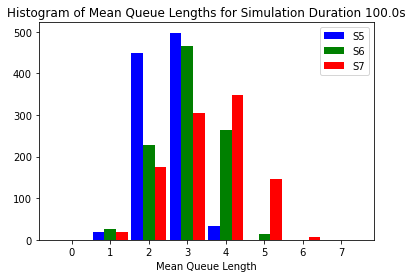

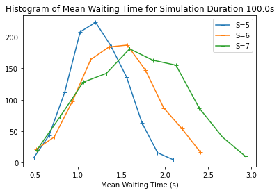

```python
# Task 2.7.1
import part2_simstudy
part2_simstudy.task_2_7_1()
```

As the queue length increases the mean and variance of the queue length also increases which makes sense since queue length has larger spread with increasing queue length. For the waiting time, the mean and variance are also increases.

### Task 2.7.2: Systems with Different Queue Capacity II

```
Simulation Duration 1000.0s
Name: Mean Queue Length for S: 5, Mean: 2.7520061960000004, Variance: 0.03130823271283642
Name: Mean Waiting Time for S: 5, Mean: 1334.3969824204567, Variance: 10402.046849671524
Name: Mean Queue Length for S: 6, Mean: 3.0534772655, Variance: 0.1414304577075308
Name: Mean Waiting Time for S: 6, Mean: 1484.3019460389694, Variance: 38800.88126207047
Name: Mean Queue Length for S: 7, Mean: 3.361061275, Variance: 0.32391904602377863
Name: Mean Waiting Time for S: 7, Mean: 1637.1959133470698, Variance: 84999.26020569874
```

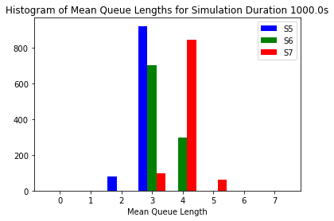

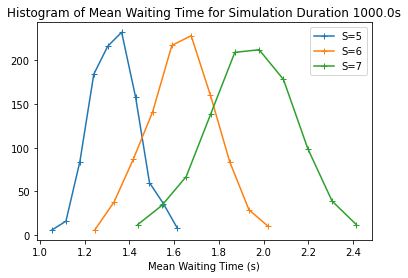

```python
# Task 2.7.2
part2_simstudy.task_2_7_2()
```

With longer simulation the means of the queue lengths and waiting times increase and the variances decrease. The situation was similar for first assignment, when we had a longer simulation the variance of the dropping probablity also decreased.

## 2.8 Analysis and General Questions

### Task 2.8.1: Systems with Different Queue Capacity

As the queue capacity increases both the variance and mean of the waiting time and queue length increases. For queue length, it is because there are more possible queue lengths as the capacity increases and it automatically makes the variance higher. For instance, when S is 5 queue length can take only 4 different values, when S is 7 queue length can take 6 different values so the spread of the samples are larger which makes mean and variance higher. For waiting time, as the capacity increases the packets can wait at the queue longer instead of being dropped. Therefore, longer waiting times are more possible when the system has higher queue capacity, which directly increases the variance and mean.

As the simulation time gets longer variance of the both queue length and waiting time decreases. Because as the simulation is longer, mean of the queue length and waiting time is calculated from more samples which means there are more samples from steady state phase. At steady state phase, distribution of the samples approximately same which means lower variance. However, at the transient phase the distribution of the samples more likely to be different which causes larger variance. Therefore, with shorter simulation time the proportion of the samples from transient phase is higher and as the simulation duration gets longer the rate of the samples from transient phase becomes smaller compared to samples from the steady state phase which is the reason of the lower variance as simulation time increases.

Also as the simulation time increases mean of the queue length and waiting time shifts to higher values. It might be because at the begining of the simulation first arrived packets are more likely to be served directly which means at the beginning of the simulation the queue length and waiting time is smaller. As the simulation time gets longer, system approaches to steady state phase where a packet is less likely to be served directly. Again with the longer simulation time the proportion of the samples from transient phase becomes lower compared to samples from steady state so the mean shifts to higher values.

### Task 2.8.2: Choosing the right number of bins

For the queue length, I considered the samples. The samples can't be more than buffer size and queue length should be an integer. Therefore, the number of the bins are chosen in a way histogram will show from 0 to possible longest queue length plus one. Also histogram shows rounded version of the samples (i.e. if the sample is 2.7 then it is at the queue length 3, if the sample is 2.2 then it is at the queue length 2).

For the waiting time, range of the samples was not obvious. At lecture notes the suggested number of intervals was square root of the sample size; therefore, initially I chose my number of bins 30 which is approximately square root of the 1000 (number of simulations). However, the histogram was hard to interpret because of the many peaks, I decided to decrease the number of bins until having a graph which is look like more continious and has a peak around mean value. As a result, I decided to use 10 bins by trying.

### Task 2.8.3: Variance Calculation

If we would have infinite number of samples, we would be sure our estimation is not biased. However, we are trying to estimate behaviour of the system by using limited number of samples and it causes a biased estimation. As an example, we are trying to calculate the mean and variance of the length of the students in a school which has 100 students. But we are trying to calculate it just by using 10 student's heights and our calculation likely to be biased. Because those all 10 students might be from basketball team which would give a wrong estimation.

To not have a biased estimation, we are using empirical variance (sample variance) formula, which is developed for the cases when there are limited number of samples.